# problema3-ck4

### Garantir o IC:

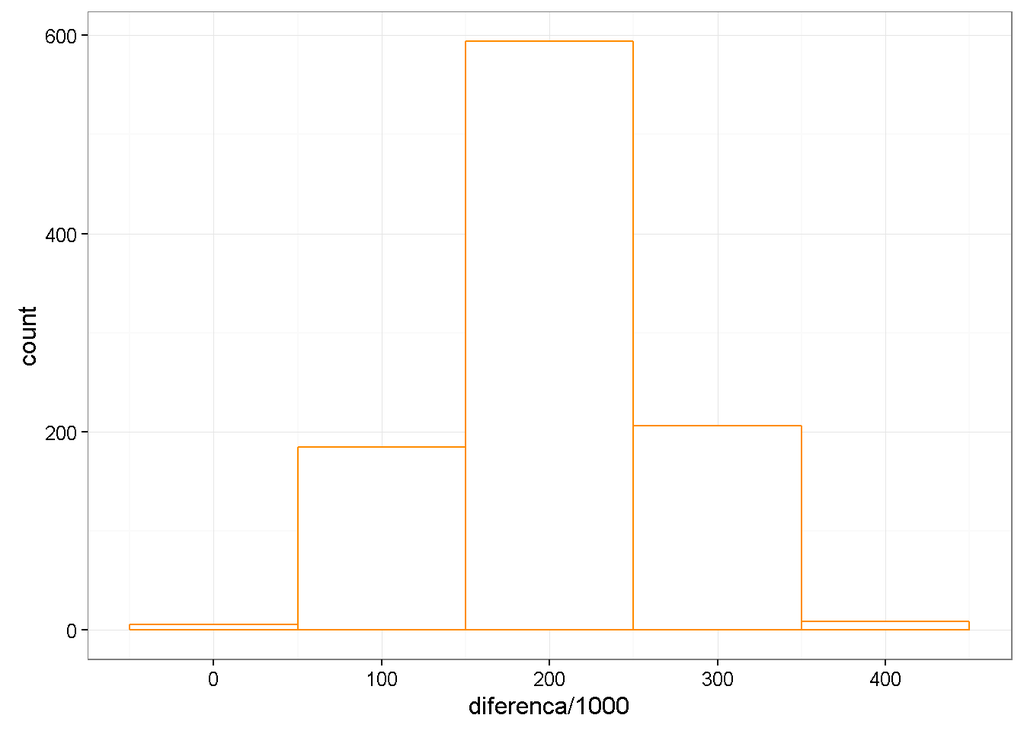

```r
#BOOTSTRAPPING IC FICÇÃO > ANIMAÇÃO --MÉDIA

repeticoes = 1000 # Experimento com 1000 reptições

#Gerando os valores para o bootrap para MÉDIA EM QUE FICÇÃO > ANIMAÇÃO
exp_com_bootstrap <- function(x, y){
  boot_x <- sample(x, size = NROW(x), replace = TRUE) # aqui é o bootstrap
  boot_y <- sample(y, size = NROW(y), replace = TRUE) # de novo!
  return(mean(boot_x) - mean(boot_y))
}

experimentos = data_frame(i = 1:num_experimentos)
experimentos = experimentos %>%
  rowwise() %>%
  mutate(diferenca = exp_com_bootstrap(ft1_31[ft1_31$Genero=="Ficção",]$Publico,ft1_31[ft1_31$Genero=="Animação",]$Publico ))



ggplot(experimentos, aes(x = diferenca/1e3)) +
  geom_histogram(binwidth = 100, colour = "darkorange", fill = "white")
```

```r
summary(experimentos)
```

```
   i            diferenca
```

Min. : 1.0 Min. : 31835  
1st Qu.: 250.8 1st Qu.:160800  
Median : 500.5 Median :204506  
Mean : 500.5 Mean :202765  
3rd Qu.: 750.2 3rd Qu.:240918  
Max. :1000.0 Max. :386550

```r
# IC com 90%:
#"Portanto em 90% com (margem +-0.5) das repetições os  ficaram entre:  "
alpha = .1

quantile(experimentos$diferenca, probs = c(alpha/2, 1 - alpha/2))
```

```
   5%       95%
```

99576.07 303149.35

```r
# IC com 95%:
#Portanto em 95% das repetições, com margem de +-2,5  os valores p ficaram entre:
alpha = .05
quantile(experimentos$diferenca, probs = c(alpha/2, 1 - alpha/2))
```

```
2.5%    97.5%
```

80839.4 320781.9

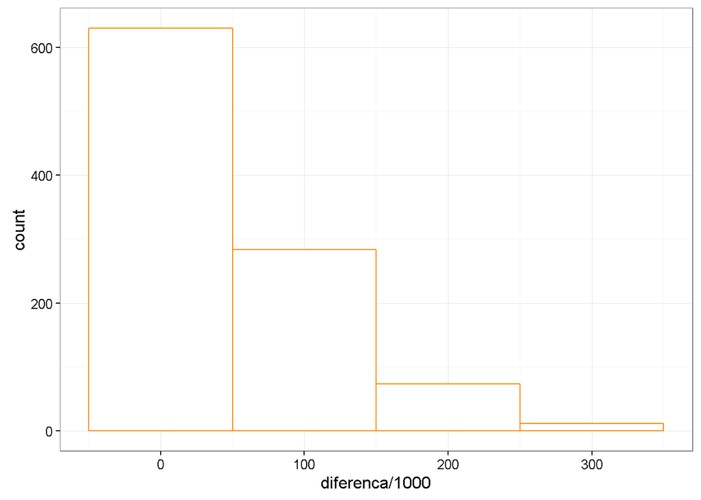

```r
##BOOTSTRAPPING IC ANIMAÇÃO > FICAÇÃO --MEDIANA
repeticoes = 1000 # Experimento com 1000 reptições

#Gerando os valores para o bootrap para MÉDIA EM QUE FICÇÃO > ANIMAÇÃO
exp_com_bootstrap <- function(x, y){
  boot_x <- sample(x, size = NROW(x), replace = TRUE) # aqui é o bootstrap
  boot_y <- sample(y, size = NROW(y), replace = TRUE) # de novo!
  return(median(boot_x) - median(boot_y))
}

experimentos = data_frame(i = 1:num_experimentos)
experimentos = experimentos %>%
  rowwise() %>%
  mutate(diferenca = exp_com_bootstrap(ft1_31[ft1_31$Genero=="Animação",]$Publico,ft1_31[ft1_31$Genero=="Ficção",]$Publico ))



ggplot(experimentos, aes(x = diferenca/1e3)) +
  geom_histogram(binwidth = 100, colour = "darkorange", fill = "white")
```

```r
summary(experimentos)
```

```
   i            diferenca
```

Min. : 1.0 Min. :-27277  
1st Qu.: 250.8 1st Qu.: 10  
Median : 500.5 Median : 12659  
Mean : 500.5 Mean : 44382  
3rd Qu.: 750.2 3rd Qu.: 71149  
Max. :1000.0 Max. :305340

```r
# IC com 90%:
#"Portanto em 90% com (margem +-0.5) das repetições os  ficaram entre:  "
alpha = .1

quantile(experimentos$diferenca, probs = c(alpha/2, 1 - alpha/2))
```

```
   5%       95%
```

-11467.05 161087.80

```r
# IC com 95%:
#Portanto em 95% das repetições, com margem de +-2,5  os valores p ficaram entre:
alpha = .05
quantile(experimentos$diferenca, probs = c(alpha/2, 1 - alpha/2))
```

```
2.5%    97.5%
```

-15786.6 218657.4

## Respondendo questão 02:

**2. Qual gênero de filmes são mais rentáveis?**

**Tratamento**

```r
#Agora limitar as informações com as quais irei tratar: Gênero e Renda e remover outliers(Renda >1000 ). Acredito que faça mais sentido, trabalhar com filmes que tiveram um Renda considerável.

#names(filmes_tratados)

ft2<-filmes_tratados[, c(3,8,10)]#Titulo, Genero e Renda


#transforma caracteres
ft2$Renda<-as.character(ft2$Renda)
#estatística descritiva sobre a tabela agrupada:
#View(ft2)

ponto<-'\\.'

for(i in 1:length(ft2$Renda)){
  ft2[i,3]<-gsub(ponto,"",ft2[i,3])}

virg<-'\\,'

for(i in 1:length(ft2$Renda)){
  ft2[i,3]<-gsub(virg,".",ft2[i,3])}

#transforma numérico
ft2$Renda<-as.numeric(ft2$Renda)
#Pega apenas quem rendeu mais de mil reais.

ft2<-filter(ft2, ft2$Renda>1000)#
ft2$Renda<-round(ft2$Renda)

media_ft2<-ft2%>%group_by(Genero)%>%summarise(mediar=mean(Renda),medianar=median(Renda))

# E novamente observamos uma diferença entre os valores de Média e Mediana em relação à Animação e Ficção, com Documentário ficando para trás.

knitr::kable(media_ft2, caption = "Média e Mediana da Renda")
```

Média e Mediana da Renda

| Genero | mediar | medianar |
| --- | --- | --- |
| Animação | 1032396.0 | 333563 |
| Documentário | 97631.1 | 18789 |
| Ficção | 2638327.2 | 179521 |

**Iniciamos aqui as repetições para um probabilidade de ocorrências e depois um bootstrapping.**

```r
#Como podemos observar, Documentários tem uma média e Mediana muito baixa, sendo assim, executremos o IC apenas em Animações e Ficção. Além disso, existe uma dispareidade muito alta entre a média e a mediana. o que indica uma variância muito alta nestes valores.

#Animação - Ficção (Mediana)
dif_mediana_31 = media_ft2[1,3] - media_ft2[3,3]

#Ficção - Animação (Média)
dif_media_31=media_ft2[3,2]-media_ft2[1,2]
#View(dif_mediana_31)
#View(dif_media_31)

print(paste("Diferença na mediana observada:", round(dif_mediana_31),".Seria Melhor animação"))
```

[1] “Diferença na mediana observada: 154042 .Seria Melhor animação”

```r
print(paste("Diferença na media observada:", round(dif_media_31), "Seria Melhor Ficção"))
```

[1] “Diferença na media observada: 1605931 Seria Melhor Ficção”

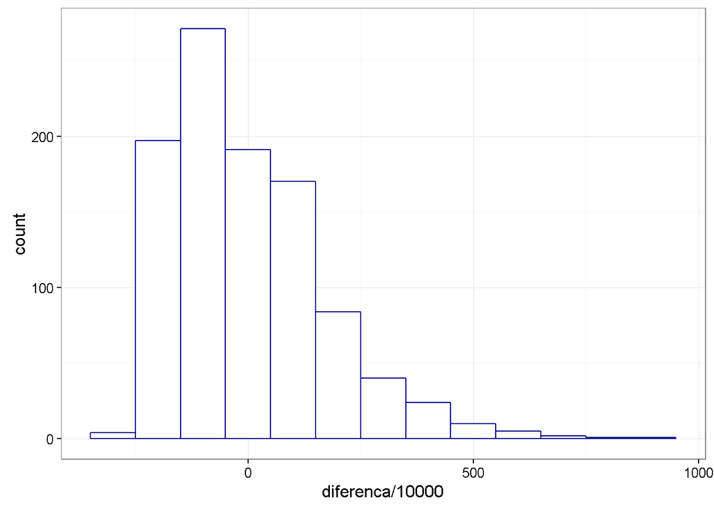

```r
ft2_31<-filter(ft2, Genero=='Animação'| Genero=="Ficção")

# Retorna a diferença nas médias entre o grupos de y
# nos índices com valor de x igual a baseline após embaralhar x.
repete_experimento_de_diff = function(x, y, baseline){
  embaralhado = x[sample(NROW(x))]
  baseline_mean = mean(y[which(embaralhado == baseline)])
  other_mean = mean(y[which(embaralhado != baseline)])
  return(other_mean - baseline_mean)
}


#O  experimento medindo as média para Ficção

num_experimentos = 1000#Rodando mil vezes
experimentos = data_frame(i = 1:num_experimentos)
experimentos = experimentos %>%
  rowwise() %>%
  mutate(diferenca = repete_experimento_de_diff(ft2_31$Genero, ft2_31$Renda, "Ficção"))

#Demora um absurdo!!!
ggplot(experimentos, aes(x = diferenca/1e4)) +
 geom_histogram(binwidth = 100, colour = "darkblue", fill = "white")
```

```r
#Tive que adicionar um valor alto para o binwith, as diferenças de valores variam muito em alguns casos.

summary(experimentos)
```

```
   i            diferenca
```

Min. : 1.0 Min. :-2595633  
1st Qu.: 250.8 1st Qu.:-1297195  
Median : 500.5 Median : -369438  
Mean : 500.5 Mean : -25740  
3rd Qu.: 750.2 3rd Qu.: 943886  
Max. :1000.0 Max. : 8741397

```r
quantas_aconteceram = length(which(experimentos$diferenca >= dif_media_31$mediar))
probabilidade = quantas_aconteceram / num_experimentos

print(paste("Este Evento ocorreu: ",quantas_aconteceram,"vezes" ))
```

[1] “Este Evento ocorreu: 155 vezes”

```r
print(paste("A probabilidade de ocorrência é de: ",probabilidade))
```

[1] “A probabilidade de ocorrência é de: 0.155”

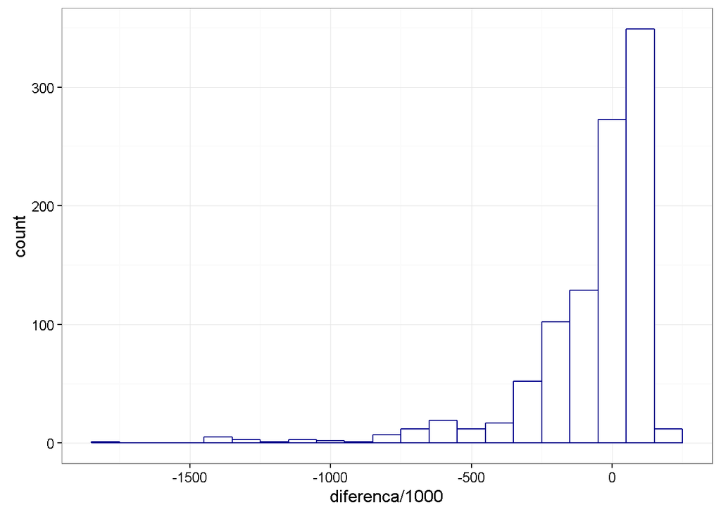

```r
#####

#O mesmo experimento para mediana em relação à Animação

repete_experimento_de_diff = function(x, y, baseline){
  embaralhado = x[sample(NROW(x))]
  baseline_median = median(y[which(embaralhado == baseline)])
  other_median = median(y[which(embaralhado != baseline)])
  return(other_median - baseline_median)
}

num_experimentos = 1000#Rodando 100
experimentos = data_frame(i = 1:num_experimentos)
experimentos = experimentos %>%
  rowwise() %>%
  mutate(diferenca = repete_experimento_de_diff(ft2_31$Genero, ft2_31$Renda, "Animação"))

#Demora um absurdo!!!
ggplot(experimentos, aes(x = diferenca/1e3)) +
 geom_histogram(binwidth = 100, colour = "darkblue", fill = "white")
```

```r
summary(experimentos)
```

```
   i            diferenca
```

Min. : 1.0 Min. :-1831163  
1st Qu.: 250.8 1st Qu.: -136109  
Median : 500.5 Median : -3652  
Mean : 500.5 Mean : -68826  
3rd Qu.: 750.2 3rd Qu.: 83818  
Max. :1000.0 Max. : 170460

```r
quantas_aconteceram = length(which(experimentos$diferenca >= dif_mediana_31$medianar))
probabilidade = quantas_aconteceram / num_experimentos

print(paste("Este Evento ocorreu: ",quantas_aconteceram,"vezes" ))
```

[1] “Este Evento ocorreu: 5 vezes”

```r
print(paste("A probabilidade de ocorrência é de: ",probabilidade))
```

[1] “A probabilidade de ocorrência é de: 0.005”

[output not shown]

### Garantir o IC:

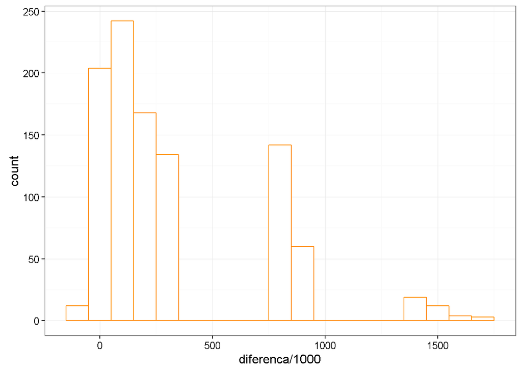

```r
##Intervalo de confiança para Animação > Ficção --MEDIANA

repeticoes = 1000 # Experimento com 1000 reptições

#Gerando os valores para o bootrap
exp_com_bootstrap <- function(x, y){
  boot_x <- sample(x, size = NROW(x), replace = TRUE) # aqui é o bootstrap
  boot_y <- sample(y, size = NROW(y), replace = TRUE) # de novo!
  return(median(boot_x) - median(boot_y))
}


experimentos = data_frame(i = 1:num_experimentos)
experimentos = experimentos %>%
  rowwise() %>%
  mutate(diferenca = exp_com_bootstrap(ft2_31[ft2_31$Genero=="Animação",]$Renda,ft2_31[ft2_31$Genero=="Ficção",]$Renda ))



ggplot(experimentos, aes(x = diferenca/1e3)) +
  geom_histogram(binwidth = 100, colour = "darkorange", fill = "white")
```

```r
summary(experimentos)
```

```
   i            diferenca
```

Min. : 1.0 Min. :-125295  
1st Qu.: 250.8 1st Qu.: 94237  
Median : 500.5 Median : 154729  
Mean : 500.5 Mean : 324534  
3rd Qu.: 750.2 3rd Qu.: 300945  
Max. :1000.0 Max. :1683616

```r
# IC com 90%:
#"Portanto em 90% com (margem +-0.5) das repetições os valores para esse genero (Animação) ficaram entre:  "
alpha = .1

quantile(experimentos$diferenca, probs = c(alpha/2, 1 - alpha/2))
```

```
  5%      95%
```

-7810.8 882890.2

```r
# IC com 95%:
#Portanto em 95% das repetições, com margem de +-2,5  os valores para esse gênero (Animação) ficaram entre:
alpha = .05
quantile(experimentos$diferenca, probs = c(alpha/2, 1 - alpha/2))
```

```
  2.5%      97.5%
```

-35763.32 1442305.00

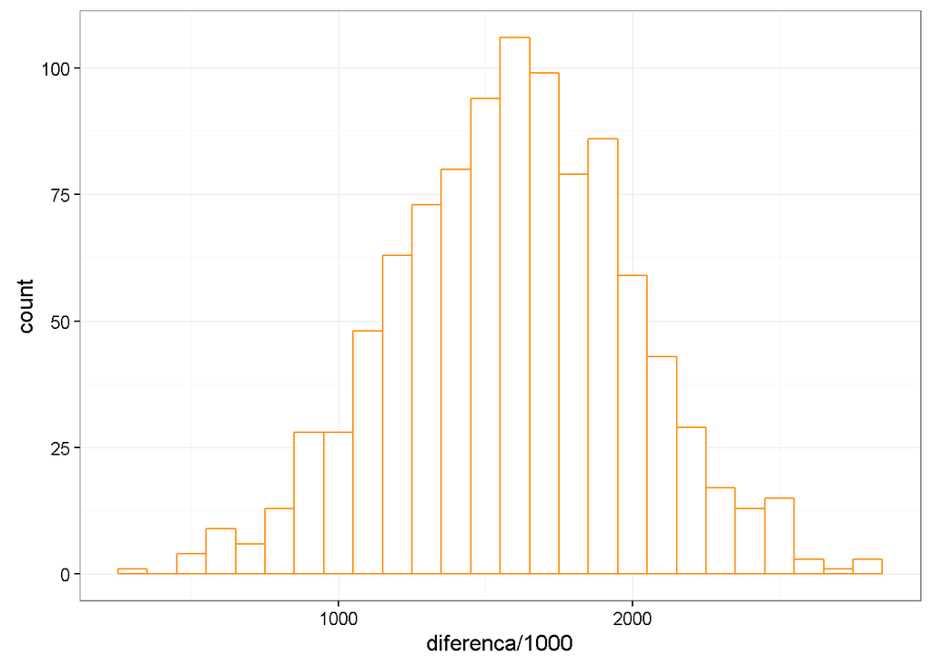

```r
###############



##Intervalo de confiança para  Ficção > aNIMAÇÃO  --MÉDIA
repeticoes = 1000 # Experimento com 1000 reptições

#Gerenaod os valores para o bootrap
exp_com_bootstrap <- function(x, y){
  boot_x <- sample(x, size = NROW(x), replace = TRUE) # aqui é o bootstrap
  boot_y <- sample(y, size = NROW(y), replace = TRUE) # de novo!
  return(mean(boot_x) - mean(boot_y))
}



experimentos = data_frame(i = 1:num_experimentos)
experimentos = experimentos %>%
  rowwise() %>%
  mutate(diferenca = exp_com_bootstrap(ft2_31[ft2_31$Genero=="Ficção",]$Renda,ft2_31[ft2_31$Genero=="Animação",]$Renda ))



ggplot(experimentos, aes(x = diferenca/1e3)) +
  geom_histogram(binwidth = 100, colour = "darkorange", fill = "white")
```

```r
summary(experimentos)
```

```
   i            diferenca
```

Min. : 1.0 Min. : 257686  
1st Qu.: 250.8 1st Qu.:1317362  
Median : 500.5 Median :1592696  
Mean : 500.5 Mean :1593628  
3rd Qu.: 750.2 3rd Qu.:1876494  
Max. :1000.0 Max. :2826963

```r
# IC com 90%:
#"Portanto em 90% com (margem +-0.5) das repetições as médias ficaram entre:  "
alpha = .1

quantile(experimentos$diferenca, probs = c(alpha/2, 1 - alpha/2))
```

```
   5%       95%
```

907116.4 2254616.9

```r
# IC com 95%:
#Portanto em 95% das repetições, com margem de +-2,5  as médias ficaram entre:
alpha = .05
quantile(experimentos$diferenca, probs = c(alpha/2, 1 - alpha/2))
```

```
 2.5%     97.5%
```

804976.3 2409880.7